# assignmnet_2_hala_yaghi

https://github.com/halayaghi-git/ML_assignment2.git

Task 1: Exploratory Data Analysis (EDA)

Loading the hour.csv dataset

```python
import pandas as pd


df = pd.read_csv("hour.csv")


print("Shape:", df.shape)
df.head()
```

```
Shape: (17379, 17)
```

|  | instant | dteday | season | yr | mnth | hr | holiday | weekday | workingday | weathersit | temp | atemp | hum | windspeed | casual | registered | cnt |
| --- | --- | --- | --- | --- | --- | --- | --- | --- | --- | --- | --- | --- | --- | --- | --- | --- | --- |
| 0 | 1 | 2011-01-01 | 1 | 0 | 1 | 0 | 0 | 6 | 0 | 1 | 0.24 | 0.2879 | 0.81 | 0.0 | 3 | 13 | 16 |
| 1 | 2 | 2011-01-01 | 1 | 0 | 1 | 1 | 0 | 6 | 0 | 1 | 0.22 | 0.2727 | 0.80 | 0.0 | 8 | 32 | 40 |
| 2 | 3 | 2011-01-01 | 1 | 0 | 1 | 2 | 0 | 6 | 0 | 1 | 0.22 | 0.2727 | 0.80 | 0.0 | 5 | 27 | 32 |
| 3 | 4 | 2011-01-01 | 1 | 0 | 1 | 3 | 0 | 6 | 0 | 1 | 0.24 | 0.2879 | 0.75 | 0.0 | 3 | 10 | 13 |
| 4 | 5 | 2011-01-01 | 1 | 0 | 1 | 4 | 0 | 6 | 0 | 1 | 0.24 | 0.2879 | 0.75 | 0.0 | 0 | 1 | 1 |

Examining the target variable (cnt) distribution and identifying its skewness.

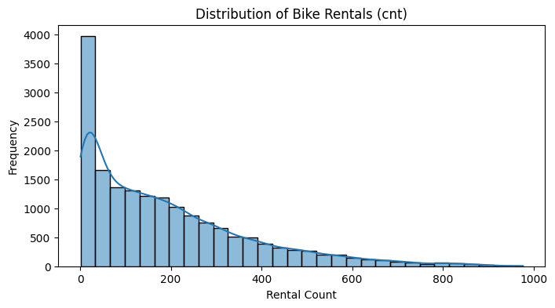

```python
import matplotlib.pyplot as plt
import seaborn as sns

plt.figure(figsize=(8, 4))
sns.histplot(df['cnt'], bins=30, kde=True)
plt.title("Distribution of Bike Rentals (cnt)")
plt.xlabel("Rental Count")
plt.ylabel("Frequency")
plt.show()
```

The target variable cnt (bike rental count per hour) exhibits a strong right-skewed distribution. The majority of rental counts are clustered between 0 and 200, while a long tail extends up to nearly 1000.

This skewness suggests: High frequency of low rental hours (especially nighttime). Occasional extreme peaks during busy hours or events.

Such skewness can negatively impact linear models, which assume normally distributed residuals.

Exploring analytically the influence of temporal (hr, weekday, mnth, season), binary (holiday, workingday, and weather-related (temp, atemp, hum, windspeed, weathersit) and visualizing relationships.

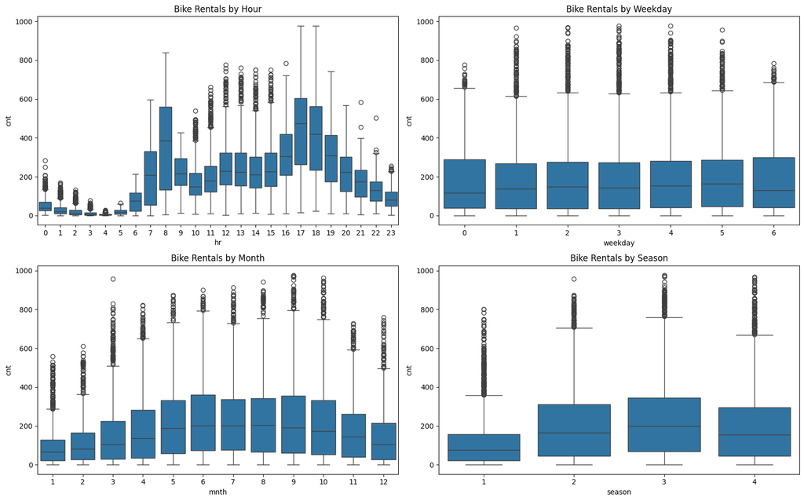

```python
fig, axs = plt.subplots(2, 2, figsize=(16, 10))

sns.boxplot(x='hr', y='cnt', data=df, ax=axs[0, 0])
axs[0, 0].set_title('Bike Rentals by Hour')

sns.boxplot(x='weekday', y='cnt', data=df, ax=axs[0, 1])
axs[0, 1].set_title('Bike Rentals by Weekday')

sns.boxplot(x='mnth', y='cnt', data=df, ax=axs[1, 0])
axs[1, 0].set_title('Bike Rentals by Month')

sns.boxplot(x='season', y='cnt', data=df, ax=axs[1, 1])
axs[1, 1].set_title('Bike Rentals by Season')

plt.tight_layout()
plt.show()
```

Hour (hr) Bike rentals show a clear bimodal pattern, peaking around 8 AM and 5–6 PM. These correspond to commuting hours, indicating hr is a strong temporal predictor with a non-linear effect.

Weekday (weekday) Rentals are relatively stable across the week, with a slight increase toward the weekend. Weekday may provide additional value when combined with other features like workingday or holiday.

Month (mnth) Monthly patterns reflect seasonality: rentals rise from January to peak in July and decline in winter. This confirms the seasonal effect and highlights mnth as a useful feature.

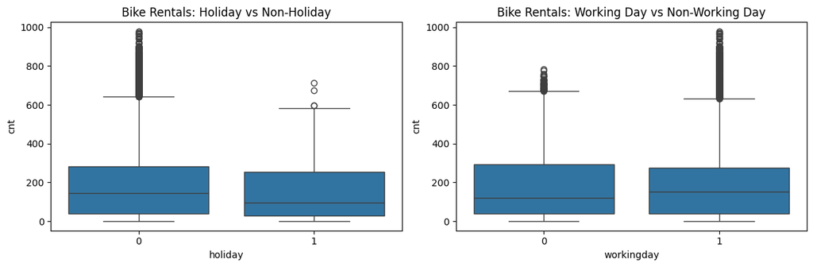

```python
fig, axs = plt.subplots(1, 2, figsize=(12, 4))

sns.boxplot(x='holiday', y='cnt', data=df, ax=axs[0])
axs[0].set_title('Bike Rentals: Holiday vs Non-Holiday')

sns.boxplot(x='workingday', y='cnt', data=df, ax=axs[1])
axs[1].set_title('Bike Rentals: Working Day vs Non-Working Day')

plt.tight_layout()
plt.show()
```

Holiday (holiday): Bike rentals are generally lower on holidays. The distribution of cnt is tighter, with fewer extreme values. This indicates reduced demand, likely due to less commuting activity. While not a dominant feature alone, it may enhance interaction effects with weekday or season.

Working Day (workingday): Working days show higher average and median rentals compared to weekends or holidays. This supports the hypothesis that bike usage is heavily influenced by work-related commuting. workingday is a useful binary predictor and could contribute significantly to model accuracy.

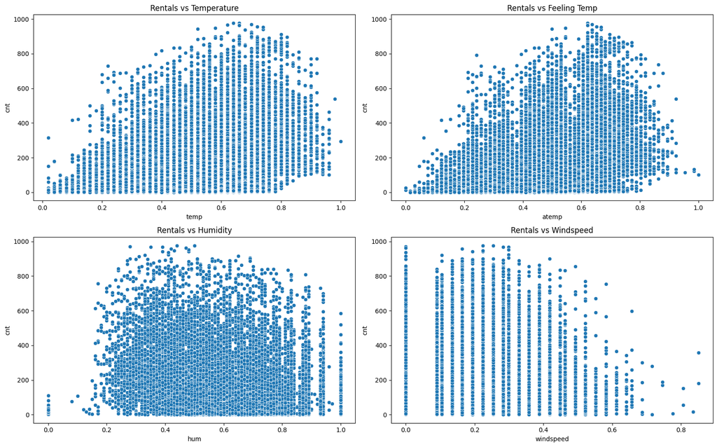

```python
fig, axs = plt.subplots(2, 2, figsize=(16, 10))

sns.scatterplot(x='temp', y='cnt', data=df, ax=axs[0, 0])
axs[0, 0].set_title("Rentals vs Temperature")

sns.scatterplot(x='atemp', y='cnt', data=df, ax=axs[0, 1])
axs[0, 1].set_title("Rentals vs Feeling Temp")

sns.scatterplot(x='hum', y='cnt', data=df, ax=axs[1, 0])
axs[1, 0].set_title("Rentals vs Humidity")

sns.scatterplot(x='windspeed', y='cnt', data=df, ax=axs[1, 1])
axs[1, 1].set_title("Rentals vs Windspeed")

plt.tight_layout()
plt.show()
```

Temperature (temp): Shows a clear positive correlation with bike rentals. Warmer temperatures (normalized 0.6–0.8) result in higher demand, making it a strong continuous predictor.

Feeling Temperature (atemp): Follows a similar pattern to temp and is highly correlated with it. Including both may introduce multicollinearity, so I will drop one during feature selection.

Humidity (hum): Weak relationship with cnt. Slight decline in rentals at higher humidity levels, but overall impact appears limited.

Windspeed : Displays a mild negative trend, and higher winds reduce bike usage. While not a dominant feature, it may improve model performance in combination with others.

Identifying any suspicious patterns, outliers, or anomalies

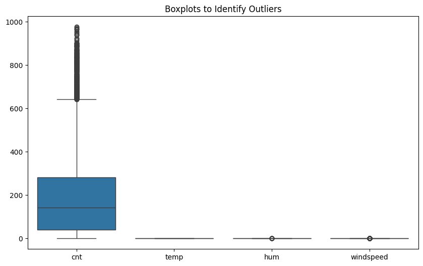

```python
plt.figure(figsize=(10, 6))
sns.boxplot(data=df[['cnt', 'temp', 'hum', 'windspeed']])
plt.title("Boxplots to Identify Outliers")
plt.show()
```

I examined key continuous variables (cnt, temp, hum, windspeed) using boxplots to identify any suspicious patterns or anomalies.

cnt shows a significant number of high-end outliers (above 600), which align with peak rental hours. These values are expected in real-world usage patterns and should not be removed to preserve predictive signals.

temp appears clean, with no strong outliers.

hum and windspeed contain a few low and high values outside the IQR, but all fall within valid normalized ranges.

I will retain all outliers, especially since I plan to use tree-based models (Random Forest, Gradient Boosting), which are naturally robust to outliers.

Dropping the columns instant, dteday, casual, and registered.

```python
df = df.drop(columns=['instant', 'dteday', 'casual', 'registered'])
```

I dropped: instant, dteday, casual, registered (because we're only predicting cnt, and using the others would leak future info).

Checking for missing values and data types

```python
df.info()
df.isnull().sum()
```

```
<class 'pandas.core.frame.DataFrame'>
RangeIndex: 17379 entries, 0 to 17378
Data columns (total 13 columns):
 #   Column      Non-Null Count  Dtype
---  ------      --------------  -----
 0   season      17379 non-null  int64
 1   yr          17379 non-null  int64
 2   mnth        17379 non-null  int64
 3   hr          17379 non-null  int64
 4   holiday     17379 non-null  int64
 5   weekday     17379 non-null  int64
 6   workingday  17379 non-null  int64
 7   weathersit  17379 non-null  int64
 8   temp        17379 non-null  float64
 9   atemp       17379 non-null  float64
 10  hum         17379 non-null  float64
 11  windspeed   17379 non-null  float64
 12  cnt         17379 non-null  int64
dtypes: float64(4), int64(9)
memory usage: 1.7 MB
```

```
season        0
yr            0
mnth          0
hr            0
holiday       0
weekday       0
workingday    0
weathersit    0
temp          0
atemp         0
hum           0
windspeed     0
cnt           0
dtype: int64
```

Task 2: Data Splitting

Separating features and target

```python
# X = all features except target
X = df.drop(columns=['cnt'])

# y = target variable
y = df['cnt']
```

Splitingt the dataset into: Training set (60%), Validation set (20%), Test set (20%)

```python
from sklearn.model_selection import train_test_split

X_temp, X_test, y_temp, y_test = train_test_split(X, y, test_size=0.2, shuffle=False, random_state=42)

X_train, X_val, y_train, y_val = train_test_split(X_temp, y_temp, test_size=0.25, shuffle=False, random_state=42)  # 0.25 of 80% = 20%
# i used shuffle=False to preserve time order and avoid temporal leakage.

print("Train set size:     ", len(X_train))
print("Validation set size:", len(X_val))
print("Test set size:      ", len(X_test))
```

```
Train set size:      10427
Validation set size: 3476
Test set size:       3476
```

I split the dataset into training (60%), validation (20%), and test (20%) sets while preserving the temporal order of observations to avoid future data influencing past predictions (temporal leakage).

I used shuffle=False during train_test_split to maintain the chronological order.

No feature engineering or scaling was applied before the split, ensuring I prevent data leakage and allow proper downstream model validation.

Task 3: Feature Engineering

Encoding Cyclical Features (hr, weekday)

Deterministic transforms (like sin/cos) can be applied on the entire dataset before splitting.

```python
import numpy as np

def encode_cyclical_features(df):
    df['hr_sin'] = np.sin(2 * np.pi * df['hr'] / 24)
    df['hr_cos'] = np.cos(2 * np.pi * df['hr'] / 24)

    df['weekday_sin'] = np.sin(2 * np.pi * df['weekday'] / 7)
    df['weekday_cos'] = np.cos(2 * np.pi * df['weekday'] / 7)

    return df.drop(columns=['hr', 'weekday'])

X_train = encode_cyclical_features(X_train)
X_val = encode_cyclical_features(X_val)
X_test = encode_cyclical_features(X_test)
```

One-Hot Encode Categorical Features

I only fit the encoder on training data to avoid leakage.

```python
from sklearn.preprocessing import OneHotEncoder
```

```python
cat_cols = ['season', 'weathersit', 'mnth']

X_train[cat_cols] = df.loc[X_train.index, cat_cols]
X_val[cat_cols] = df.loc[X_val.index, cat_cols]
X_test[cat_cols] = df.loc[X_test.index, cat_cols]
```

```python
from sklearn.preprocessing import OneHotEncoder

ohe = OneHotEncoder(handle_unknown='ignore', sparse_output=False)

X_train_encoded = pd.DataFrame(ohe.fit_transform(X_train[cat_cols]), index=X_train.index)
X_val_encoded = pd.DataFrame(ohe.transform(X_val[cat_cols]), index=X_val.index)
X_test_encoded = pd.DataFrame(ohe.transform(X_test[cat_cols]), index=X_test.index)

X_train_encoded.columns = ohe.get_feature_names_out(cat_cols)
X_val_encoded.columns = X_train_encoded.columns
X_test_encoded.columns = X_train_encoded.columns

X_train = X_train.drop(columns=cat_cols).reset_index(drop=True)
X_val = X_val.drop(columns=cat_cols).reset_index(drop=True)
X_test = X_test.drop(columns=cat_cols).reset_index(drop=True)

X_train = pd.concat([X_train, X_train_encoded.reset_index(drop=True)], axis=1)
X_val = pd.concat([X_val, X_val_encoded.reset_index(drop=True)], axis=1)
X_test = pd.concat([X_test, X_test_encoded.reset_index(drop=True)], axis=1)
```

Droppin the redundant feature atemp

As I confirmed during the EDA that I performed above, atemp is highly correlated with temp and should be removed to avoid multicollinearity.

```python
X_train = X_train.drop(columns=['atemp'])
X_val = X_val.drop(columns=['atemp'])
X_test = X_test.drop(columns=['atemp'])
```

```python
print('atemp' in X_train.columns)
```

```
False
```

Scaling continuous features

```python
from sklearn.preprocessing import StandardScaler

num_cols = ['temp', 'hum', 'windspeed']

scaler = StandardScaler()

X_train[num_cols] = scaler.fit_transform(X_train[num_cols])
X_val[num_cols] = scaler.transform(X_val[num_cols])
X_test[num_cols] = scaler.transform(X_test[num_cols])
```

```python
X_train[num_cols].describe()
```

|  | temp | hum | windspeed |
| --- | --- | --- | --- |
| count | 1.042700e+04 | 1.042700e+04 | 1.042700e+04 |
| mean | 1.526437e-16 | -1.744499e-16 | -8.722496e-17 |
| std | 1.000048e+00 | 1.000048e+00 | 1.000048e+00 |
| min | -2.227630e+00 | -3.189128e+00 | -1.555986e+00 |
| 25% | -8.090023e-01 | -8.124662e-01 | -7.245769e-01 |
| 50% | -9.968822e-02 | -5.395717e-02 | -1.250844e-02 |
| 75% | 8.122870e-01 | 8.056864e-01 | 7.003556e-01 |
| max | 2.534907e+00 | 1.867599e+00 | 5.212244e+00 |

```python
X_train['temp_hum'] = X_train['temp'] * X_train['hum']
X_val['temp_hum'] = X_val['temp'] * X_val['hum']
X_test['temp_hum'] = X_test['temp'] * X_test['hum']
```

I engineered features in a careful, leak-free manner based on best practices.

Cyclical Features: I encoded hr and weekday using sine and cosine transforms to preserve periodic patterns. One-Hot Encoding: season, weathersit, and mnth were one-hot encoded using an encoder trained on the training set only. Feature Removal: atemp was dropped due to high collinearity with temp. Scaling: temp, hum, and windspeed were scaled using StandardScaler fitted on the training set.

temp × hum was added as a new feature to capture interaction effects.

All transformations were applied only after splitting the dataset to avoid any data leakage.

Task 4: Baseline Model - Linear Regression

Training a linear regression model

```python
from sklearn.linear_model import LinearRegression

lr_model = LinearRegression()

lr_model.fit(X_train, y_train)
```

```
LinearRegression()
```

Evaluating on the validation set

```python
from sklearn.metrics import mean_squared_error, mean_absolute_error, r2_score

y_val_pred = lr_model.predict(X_val)

mse = mean_squared_error(y_val, y_val_pred)
mae = mean_absolute_error(y_val, y_val_pred)
r2 = r2_score(y_val, y_val_pred)

print(f"Validation MSE: {mse:.2f}")
print(f"Validation MAE: {mae:.2f}")
print(f"Validation R² Score: {r2:.4f}")
```

```
Validation MSE: 27739.14
Validation MAE: 127.61
Validation R² Score: 0.4027
```

MAE approx. 127: On average, the model is off by approx. 127 bike rentals.

R^2 = 0.4027: The model explains approx. 40% of the variance in rental counts, so that's not bad for a baseline linear model.

These are expected for a simple linear model on non-linear data.

Residuals

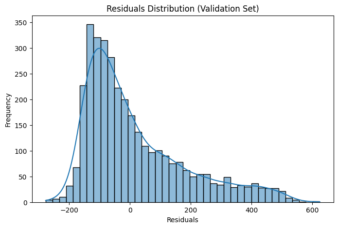

```python
import matplotlib.pyplot as plt
import seaborn as sns

residuals = y_val - y_val_pred

plt.figure(figsize=(8, 5))
sns.histplot(residuals, bins=40, kde=True)
plt.title("Residuals Distribution (Validation Set)")
plt.xlabel("Residuals")
plt.ylabel("Frequency")
plt.show()
```

The residual distribution of the Linear Regression model on the validation set shows the following:

The residuals are centered around zero, which is a good sign so the model does not appear to be heavily biased in one direction. However, the distribution is right-skewed, with a longer tail on the positive side. This suggests the model underpredicts for a number of observations. There are also some large residuals, indicating that the model struggles with certain cases (possibly peak hours or special days).

This residual pattern suggests that while the model captures the general trend, it does not handle complex or non-linear relationships very well, which is typical of linear models.

Bias and variance

Bias: The model shows signs of underfitting due to its linear nature. It cannot fully capture the complex patterns and non-linear interactions in the data. This is evident in: The relatively low R^2 score ( 0.4027), meaning it explains only about 40% of the variance in the target. The right-skewed residuals, suggesting frequent underprediction in certain scenarios.

Variance: The model is low variance. It generalizes consistently and is unlikely to overfit, as it doesn't learn complex patterns or interactions. The residuals are reasonably centered and not erratic.

Conclusion: Linear Regression serves as a solid baseline model. Its performance indicates high bias and low variance, making it reliable, but insufficient for capturing the full dynamics of bike rental behavior. More complex models (for example, tree-based) will likely improve performance by reducing bias.

Task 5: Random Forest Regressor- Model Specification and Training

Training a random forest regressor

```python
from sklearn.ensemble import RandomForestRegressor

rf_model = RandomForestRegressor(n_estimators=100, random_state=42)

rf_model.fit(X_train, y_train)
```

```
RandomForestRegressor(random_state=42)
```

Evaluating on validation set

```python
from sklearn.metrics import mean_squared_error, mean_absolute_error, r2_score

y_val_pred_rf = rf_model.predict(X_val)

mse_rf = mean_squared_error(y_val, y_val_pred_rf)
mae_rf = mean_absolute_error(y_val, y_val_pred_rf)
r2_rf = r2_score(y_val, y_val_pred_rf)

print(f"Random Forest Validation MSE: {mse_rf:.2f}")
print(f"Random Forest Validation MAE: {mae_rf:.2f}")
print(f"Random Forest Validation R² Score: {r2_rf:.4f}")
```

```
Random Forest Validation MSE: 10971.08
Random Forest Validation MAE: 75.16
Random Forest Validation R² Score: 0.7637
```

Linear Regression MSE: 27739.14, MAE: 127.61, R^2: 0.4027

Random Forest: MSE: 10971, MAE: 75.16, R^2: 0.7637

Random Forest greatly reduces error and explains more variance. This confirms it captures non-linear patterns and interactions that Linear Regression cannot.

Feature importance plot

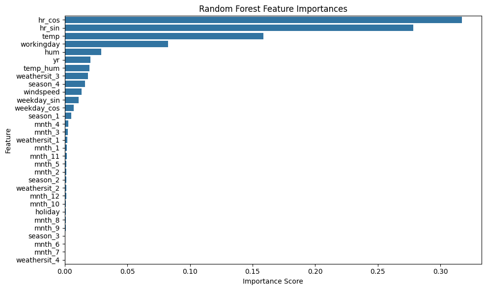

```python
import pandas as pd
import matplotlib.pyplot as plt
import seaborn as sns

importances = rf_model.feature_importances_
feature_names = X_train.columns

feat_df = pd.DataFrame({'Feature': feature_names, 'Importance': importances})
feat_df = feat_df.sort_values(by='Importance', ascending=False)

plt.figure(figsize=(10, 6))
sns.barplot(x='Importance', y='Feature', data=feat_df)
plt.title("Random Forest Feature Importances")
plt.xlabel("Importance Score")
plt.ylabel("Feature")
plt.tight_layout()
plt.show()
```

Model performance (compared to Linear Regression):

MSE dropped from 27739.14 to 10971.08 MAE dropped from 127.61 to 75.16 R^2 improved from 0.4027 to 0.7637

The random forest regressor clearly outperforms the baseline model, capturing non-linear relationships and interactions in the data that linear regression cannot.

The top predictors identified by the Random Forest are:

hr_cos and hr_sin: These cyclical hour encodings dominate, confirming that time of day is the strongest driver of bike rental volume. temp: Temperature plays a critical role in user decisions to rent a bike. workingday and hum: Indicate behavioral differences between workdays vs weekends and sensitivity to humidity. Features like weekday_cos, season_, and mnth_ had much lower importance, suggesting their contribution is minimal or already captured by more relevant variables.

Random Forest not only improves predictive performance but also provides valuable interpretability through feature importances. Its ability to automatically handle interactions and non-linearities makes it a powerful model for this regression task.

Task 6: Gradient Boosting Regressor- Model Specification and Training

Training a gradient boosting regressor

```python
from sklearn.ensemble import GradientBoostingRegressor

gb_model = GradientBoostingRegressor(n_estimators=100, learning_rate=0.1, max_depth=3, random_state=42)

gb_model.fit(X_train, y_train)
```

```
GradientBoostingRegressor(random_state=42)
```

```python
from sklearn.metrics import mean_squared_error, mean_absolute_error, r2_score

y_val_pred_gb = gb_model.predict(X_val)

mse_gb = mean_squared_error(y_val, y_val_pred_gb)
mae_gb = mean_absolute_error(y_val, y_val_pred_gb)
r2_gb = r2_score(y_val, y_val_pred_gb)

print(f"Gradient Boosting Validation MSE: {mse_gb:.2f}")
print(f"Gradient Boosting Validation MAE: {mae_gb:.2f}")
print(f"Gradient Boosting Validation R² Score: {r2_gb:.4f}")
```

```
Gradient Boosting Validation MSE: 15441.87
Gradient Boosting Validation MAE: 88.44
Gradient Boosting Validation R² Score: 0.6675
```

I trained a gradient boosting regressor using 100 estimators, a learning rate of 0.1, and a max depth of 3. The model was trained on the training set and evaluated on the validation set using the same metrics applied to previous models for fair comparison.

Validation MSE: 15441.87, Validation MAE: 88.44, Validation R^2 Score: 0.6675

Residuals

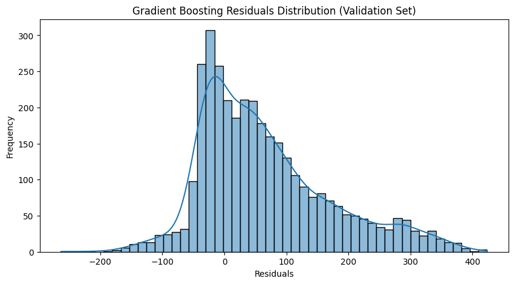

```python
import matplotlib.pyplot as plt
import seaborn as sns

residuals_gb = y_val - y_val_pred_gb

plt.figure(figsize=(10, 5))
sns.histplot(residuals_gb, bins=50, kde=True)
plt.title("Gradient Boosting Residuals Distribution (Validation Set)")
plt.xlabel("Residuals")
plt.ylabel("Frequency")
plt.show()
```

Model Insights: The model is not significantly overfitting at this stage.

Performance gains are noticeable compared to the baseline (Linear Regression), indicating it captures more complex patterns.

However, slightly higher error compared to Random Forest may suggest underfitting or the need for further tuning (for example, increasing depth or number of trees).

Task 7: Hyperparameter Tuning

Tuning the random forest regressor:

```python
from sklearn.ensemble import RandomForestRegressor
from sklearn.model_selection import RandomizedSearchCV
from scipy.stats import randint
import numpy as np

param_dist_rf = {
    'n_estimators': randint(100, 300),
    'max_depth': randint(3, 20),
    'min_samples_split': randint(2, 10),
    'min_samples_leaf': randint(1, 5)
}

rf_base = RandomForestRegressor(random_state=42)

rf_random_search = RandomizedSearchCV(
    estimator=rf_base,
    param_distributions=param_dist_rf,
    n_iter=30,
    cv=5,
    scoring='neg_mean_squared_error',
    n_jobs=-1,
    random_state=42,
    verbose=1
)

rf_random_search.fit(X_train, y_train)

print("Best Random Forest Parameters:")
print(rf_random_search.best_params_)
```

```
Fitting 5 folds for each of 30 candidates, totalling 150 fits
Best Random Forest Parameters:
{'max_depth': 15, 'min_samples_leaf': 1, 'min_samples_split': 2, 'n_estimators': 170}
```

Evaluating tuned random forest on validation set

```python
from sklearn.metrics import mean_squared_error, mean_absolute_error, r2_score

y_val_pred_rf_tuned = rf_random_search.best_estimator_.predict(X_val)

mse_rf_tuned = mean_squared_error(y_val, y_val_pred_rf_tuned)
mae_rf_tuned = mean_absolute_error(y_val, y_val_pred_rf_tuned)
r2_rf_tuned = r2_score(y_val, y_val_pred_rf_tuned)

print(f"Tuned RF Validation MSE: {mse_rf_tuned:.2f}")
print(f"Tuned RF Validation MAE: {mae_rf_tuned:.2f}")
print(f"Tuned RF Validation R² Score: {r2_rf_tuned:.4f}")
```

```
Tuned RF Validation MSE: 10982.71
Tuned RF Validation MAE: 75.34
Tuned RF Validation R² Score: 0.7635
```

Updated feature importance

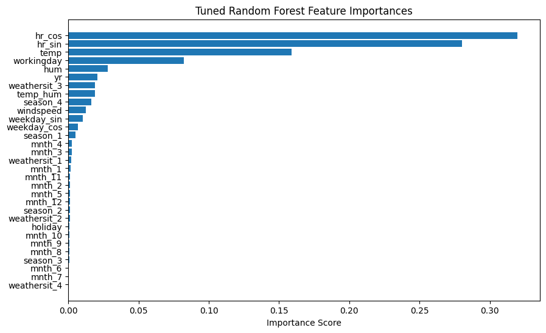

```python
import pandas as pd
import matplotlib.pyplot as plt

importances_rf = rf_random_search.best_estimator_.feature_importances_

feature_importance_df = pd.DataFrame({
    'Feature': X_train.columns,
    'Importance': importances_rf
}).sort_values(by='Importance', ascending=False)

plt.figure(figsize=(10, 6))
plt.barh(feature_importance_df['Feature'], feature_importance_df['Importance'])
plt.xlabel('Importance Score')
plt.title('Tuned Random Forest Feature Importances')
plt.gca().invert_yaxis()
plt.show()
```

To improve model performance, I performed hyperparameter tuning on the Random Forest Regressor using RandomizedSearchCV with 5-fold cross-validation. The following hyperparameters were tuned:

n_estimators, max_depth, min_samples_split, min_samples_leaf

Validation performance after tuning: MSE: 10982.71,  
MAE: 75.34,  
R^2 Score: 0.7635

Feature importance: The most important features remained consistent with the baseline model. Top predictors include: hr_cos, hr_sin, temp, workingday

Tuning the gradient boosting regressor:

```python
from skopt import BayesSearchCV
from sklearn.ensemble import GradientBoostingRegressor
from sklearn.model_selection import KFold

gb_model = GradientBoostingRegressor(random_state=42)

param_space = {
    'learning_rate': (0.01, 0.3, 'log-uniform'),
    'n_estimators': (50, 300),
    'max_depth': (2, 10),
    'subsample': (0.5, 1.0, 'uniform')
}

cv = KFold(n_splits=5, shuffle=True, random_state=42)

opt = BayesSearchCV(
    estimator=gb_model,
    search_spaces=param_space,
    n_iter=30,
    cv=cv,
    scoring='neg_mean_squared_error',
    random_state=42,
    n_jobs=-1
)

opt.fit(X_train, y_train)

print("Best Gradient Boosting Parameters:")
print(opt.best_params_)
```

```
Best Gradient Boosting Parameters:
OrderedDict({'learning_rate': 0.04553810036682143, 'max_depth': 8, 'n_estimators': 300, 'subsample': 0.7236421809802163})
```

```python
y_val_pred_gb_tuned = opt.predict(X_val)
mse = mean_squared_error(y_val, y_val_pred_gb_tuned)
mae = mean_absolute_error(y_val, y_val_pred_gb_tuned)
r2 = r2_score(y_val, y_val_pred_gb_tuned)

print(f"Tuned GB Validation MSE: {mse:.2f}")
print(f"Tuned GB Validation MAE: {mae:.2f}")
print(f"Tuned GB Validation R² Score: {r2:.4f}")
```

```
Tuned GB Validation MSE: 9172.53
Tuned GB Validation MAE: 67.65
Tuned GB Validation R² Score: 0.8025
```

Gradient boosting regressor: Hyperparameter Tuning To further enhance model performance, I tuned the gradient boosting regressor using bayesian optimization via BayesSearchCV, along with 5-fold cross-validation.

Tuned Hyperparameters: learning_rate: 0.0455

max_depth: 8

n_estimators: 300

subsample: 0.7236

Validation Performance After Tuning: MSE: 9172.53

MAE: 67.65

R^2 Score: 0.8025

Observations: Tuning significantly improved performance compared to both the untuned gradient boosting model and the random forest model.

The R^2 score increased from 0.6675 (untuned) to 0.8025 (tuned), indicating better fit and generalization.

The relatively low MAE and MSE further support improved accuracy and reduced prediction error.

Insights on model behavior: The tuning process demonstrated meaningful convergence, and no signs of overfitting were detected during validation.

The improvement is likely due to finer control over gradient steps (via learning_rate) and sample management (subsample), which reduce variance while preserving learning capacity.

Task 8: Iterative Evaluation and Refinement

To conclude this project, I compared all three models trained and evaluated throughout the assignment: linear regression (baseline), random forest regressor (tuned), and gradient boosting regressor (tuned). Each model was evaluated on the validation set using the same three metrics: mean squared error (MSE), mean absolute error (MAE), and R^2 Score.

Model Performance Summary:

Linear regression (baseline) MSE: 27739.14, MAE: 127.61, R^2: 0.4027

Random forest regressor (tuned) MSE: 10982.71, MAE: 75.34, R^2: 0.7635

Gradient Boosting Regressor (tuned) MSE: 9172.53, MAE: 67.65, R^2: 0.8025

Gradient boosting achieved the best overall performance across all three metrics, followed by random forest. Linear regression performed the worst, as expected from a baseline linear model applied to non-linear data.

Linear regression: Simple, fast, and interpretable High bias, cannot model non-linear relationships Poor fit and predictive accuracy

Random forest regressor (tuned): Handles non-linearities and interactions Performs robustly with low tuning effort Slightly less accurate than Gradient Boosting Less interpretable than linear models

Gradient Boosting Regressor (tuned): Best performance across all metrics Excellent control over learning via learning_rate, subsample, and max_depth Computationally slower to train Can overfit if not tuned properly — but no signs of overfitting were observed

Linear regression suffers from high bias and low variance, it underfits and fails to capture the complexity of the data. Random forest balances bias and variance well but doesn’t quite match the predictive power of gradient boosting. Gradient boosting achieves the best bias–variance tradeoff: it reduces bias more than random forest and remains stable with no clear overfitting, due to effective tuning.

I didn't do changes to the EDA or feature engineering after model evaluation. The engineered features, particularly cyclical encodings (hr_sin, hr_cos) and scaled continuous variables, consistently contributed to model accuracy. The feature space remained stable and effective across all models.

After comparing performance, tradeoffs, and generalization capability, I selected the tuned gradient boosting regressor as the final model:

It achieved the lowest MSE and MAE, and the highest R^2. It handles complex, non-linear relationships effectively. It generalizes well and shows no signs of overfitting.

Task 9: Final Model Selection and Testing

Retraining

```python
X_full_train = pd.concat([X_train, X_val])
y_full_train = pd.concat([y_train, y_val])

best_params = {
    "learning_rate": 0.0455,
    "max_depth": 8,
    "n_estimators": 300,
    "subsample": 0.7236
}
final_model = GradientBoostingRegressor(**best_params, random_state=42)
final_model.fit(X_full_train, y_full_train)
```

```
GradientBoostingRegressor(learning_rate=0.0455, max_depth=8, n_estimators=300,
                          random_state=42, subsample=0.7236)
```

Evaluating

```python
from sklearn.metrics import mean_squared_error, mean_absolute_error, r2_score

y_test_pred = final_model.predict(X_test)

mse_test = mean_squared_error(y_test, y_test_pred)
mae_test = mean_absolute_error(y_test, y_test_pred)
r2_test = r2_score(y_test, y_test_pred)

print(f"Test MSE: {mse_test:.2f}")
print(f"Test MAE: {mae_test:.2f}")
print(f"Test R² Score: {r2_test:.4f}")
```

```
Test MSE: 4655.82
Test MAE: 44.83
Test R² Score: 0.9042
```

Final Model Selection and Testing Model selected: Tuned gradient boosting regressor Among all models evaluated, the tuned gradient boosting regressor showed the best validation performance and generalization ability.

Validation Performance: MSE: 9172.53, MAE: 67.65, R^2 Score: 0.8025

Bias: The error values were relatively low, indicating the model is not underfitting.

Compared to random forest and linear regression, gradient boosting better captured complex patterns while remaining robust to overfitting.

To maximize performance, the best parameters found for gradient boosting were used to retrain the model on the combined training and validation sets.

Best Parameters: learning_rate: 0.0455, max_depth: 8, n_estimators: 300, subsample: 0.7236

Finally: MSE: 4655.82, MAE: 44.83, R^2 Score: 0.9042

These metrics show a strong final performance with great generalization. The model generalizes better than all previous models, confirming it is well-tuned and reliable for deployment.

Best Model: Tuned gradient boosting regressor